# Risk Factor Analysis

## Outcome Variable

**Outcome Variable:** ever_co

## Predictor Variables

**Intervention Variable:** month

**Adjustment Set:**

unadjusted

## Stratifying Variables

The analysis was stratified on these variable(s):

- agecat
- studyid
- country

## Data Summary

| agecat | studyid | country | month | ever_co | n_cell | n |
| --- | --- | --- | --- | --- | --- | --- |
| 0-24 months | CMC-V-BCS-2002 | INDIA | 1 | 0 | 22 | 373 |
| 0-24 months | CMC-V-BCS-2002 | INDIA | 1 | 1 | 6 | 373 |
| 0-24 months | CMC-V-BCS-2002 | INDIA | 2 | 0 | 17 | 373 |
| 0-24 months | CMC-V-BCS-2002 | INDIA | 2 | 1 | 7 | 373 |
| 0-24 months | CMC-V-BCS-2002 | INDIA | 3 | 0 | 20 | 373 |
| 0-24 months | CMC-V-BCS-2002 | INDIA | 3 | 1 | 6 | 373 |
| 0-24 months | CMC-V-BCS-2002 | INDIA | 4 | 0 | 24 | 373 |
| 0-24 months | CMC-V-BCS-2002 | INDIA | 4 | 1 | 5 | 373 |
| 0-24 months | CMC-V-BCS-2002 | INDIA | 5 | 0 | 35 | 373 |
| 0-24 months | CMC-V-BCS-2002 | INDIA | 5 | 1 | 8 | 373 |
| 0-24 months | CMC-V-BCS-2002 | INDIA | 6 | 0 | 29 | 373 |
| 0-24 months | CMC-V-BCS-2002 | INDIA | 6 | 1 | 8 | 373 |
| 0-24 months | CMC-V-BCS-2002 | INDIA | 7 | 0 | 29 | 373 |
| 0-24 months | CMC-V-BCS-2002 | INDIA | 7 | 1 | 4 | 373 |
| 0-24 months | CMC-V-BCS-2002 | INDIA | 8 | 0 | 32 | 373 |
| 0-24 months | CMC-V-BCS-2002 | INDIA | 8 | 1 | 9 | 373 |
| 0-24 months | CMC-V-BCS-2002 | INDIA | 9 | 0 | 15 | 373 |
| 0-24 months | CMC-V-BCS-2002 | INDIA | 9 | 1 | 8 | 373 |
| 0-24 months | CMC-V-BCS-2002 | INDIA | 10 | 0 | 17 | 373 |
| 0-24 months | CMC-V-BCS-2002 | INDIA | 10 | 1 | 2 | 373 |
| 0-24 months | CMC-V-BCS-2002 | INDIA | 11 | 0 | 30 | 373 |
| 0-24 months | CMC-V-BCS-2002 | INDIA | 11 | 1 | 11 | 373 |
| 0-24 months | CMC-V-BCS-2002 | INDIA | 12 | 0 | 17 | 373 |
| 0-24 months | CMC-V-BCS-2002 | INDIA | 12 | 1 | 12 | 373 |
| 0-24 months | CMIN | BANGLADESH | 1 | 0 | 18 | 271 |
| 0-24 months | CMIN | BANGLADESH | 1 | 1 | 10 | 271 |
| 0-24 months | CMIN | BANGLADESH | 2 | 0 | 22 | 271 |
| 0-24 months | CMIN | BANGLADESH | 2 | 1 | 12 | 271 |
| 0-24 months | CMIN | BANGLADESH | 3 | 0 | 17 | 271 |
| 0-24 months | CMIN | BANGLADESH | 3 | 1 | 3 | 271 |

[output cut: 1674 more lines]

The following strata were considered:

- agecat: 0-24 months, studyid: CMC-V-BCS-2002, country: INDIA
- agecat: 0-24 months, studyid: CMIN, country: BANGLADESH
- agecat: 0-24 months, studyid: CONTENT, country: PERU
- agecat: 0-24 months, studyid: EE, country: PAKISTAN
- agecat: 0-24 months, studyid: GMS-Nepal, country: NEPAL
- agecat: 0-24 months, studyid: Guatemala BSC, country: GUATEMALA
- agecat: 0-24 months, studyid: iLiNS-Zinc, country: BURKINA FASO
- agecat: 0-24 months, studyid: IRC, country: INDIA
- agecat: 0-24 months, studyid: Keneba, country: GAMBIA
- agecat: 0-24 months, studyid: LCNI-5, country: MALAWI
- agecat: 0-24 months, studyid: MAL-ED, country: BANGLADESH
- agecat: 0-24 months, studyid: MAL-ED, country: BRAZIL
- agecat: 0-24 months, studyid: MAL-ED, country: INDIA
- agecat: 0-24 months, studyid: MAL-ED, country: NEPAL
- agecat: 0-24 months, studyid: MAL-ED, country: PERU
- agecat: 0-24 months, studyid: MAL-ED, country: SOUTH AFRICA
- agecat: 0-24 months, studyid: MAL-ED, country: TANZANIA, UNITED REPUBLIC OF
- agecat: 0-24 months, studyid: NIH-Birth, country: BANGLADESH
- agecat: 0-24 months, studyid: PROBIT, country: BELARUS
- agecat: 0-24 months, studyid: ResPak, country: PAKISTAN
- agecat: 0-24 months, studyid: SAS-CompFeed, country: INDIA
- agecat: 0-24 months, studyid: SAS-FoodSuppl, country: INDIA
- agecat: 0-24 months, studyid: TanzaniaChild2, country: TANZANIA, UNITED REPUBLIC OF
- agecat: 0-24 months, studyid: ZVITAMBO, country: ZIMBABWE
- agecat: 0-6 months, studyid: CMC-V-BCS-2002, country: INDIA
- agecat: 0-6 months, studyid: CMIN, country: BANGLADESH
- agecat: 0-6 months, studyid: CONTENT, country: PERU
- agecat: 0-6 months, studyid: EE, country: PAKISTAN
- agecat: 0-6 months, studyid: GMS-Nepal, country: NEPAL
- agecat: 0-6 months, studyid: Guatemala BSC, country: GUATEMALA
- agecat: 0-6 months, studyid: IRC, country: INDIA
- agecat: 0-6 months, studyid: Keneba, country: GAMBIA
- agecat: 0-6 months, studyid: LCNI-5, country: MALAWI
- agecat: 0-6 months, studyid: MAL-ED, country: BANGLADESH
- agecat: 0-6 months, studyid: MAL-ED, country: BRAZIL
- agecat: 0-6 months, studyid: MAL-ED, country: INDIA
- agecat: 0-6 months, studyid: MAL-ED, country: NEPAL
- agecat: 0-6 months, studyid: MAL-ED, country: PERU
- agecat: 0-6 months, studyid: MAL-ED, country: SOUTH AFRICA
- agecat: 0-6 months, studyid: MAL-ED, country: TANZANIA, UNITED REPUBLIC OF
- agecat: 0-6 months, studyid: NIH-Birth, country: BANGLADESH
- agecat: 0-6 months, studyid: PROBIT, country: BELARUS
- agecat: 0-6 months, studyid: ResPak, country: PAKISTAN
- agecat: 0-6 months, studyid: SAS-CompFeed, country: INDIA
- agecat: 0-6 months, studyid: SAS-FoodSuppl, country: INDIA
- agecat: 0-6 months, studyid: TanzaniaChild2, country: TANZANIA, UNITED REPUBLIC OF
- agecat: 0-6 months, studyid: ZVITAMBO, country: ZIMBABWE
- agecat: 6-24 months, studyid: CMC-V-BCS-2002, country: INDIA
- agecat: 6-24 months, studyid: CMIN, country: BANGLADESH
- agecat: 6-24 months, studyid: CONTENT, country: PERU
- agecat: 6-24 months, studyid: EE, country: PAKISTAN
- agecat: 6-24 months, studyid: GMS-Nepal, country: NEPAL
- agecat: 6-24 months, studyid: Guatemala BSC, country: GUATEMALA
- agecat: 6-24 months, studyid: iLiNS-Zinc, country: BURKINA FASO
- agecat: 6-24 months, studyid: IRC, country: INDIA
- agecat: 6-24 months, studyid: Keneba, country: GAMBIA
- agecat: 6-24 months, studyid: LCNI-5, country: MALAWI
- agecat: 6-24 months, studyid: MAL-ED, country: BANGLADESH
- agecat: 6-24 months, studyid: MAL-ED, country: BRAZIL
- agecat: 6-24 months, studyid: MAL-ED, country: INDIA
- agecat: 6-24 months, studyid: MAL-ED, country: NEPAL
- agecat: 6-24 months, studyid: MAL-ED, country: PERU
- agecat: 6-24 months, studyid: MAL-ED, country: SOUTH AFRICA
- agecat: 6-24 months, studyid: MAL-ED, country: TANZANIA, UNITED REPUBLIC OF
- agecat: 6-24 months, studyid: NIH-Birth, country: BANGLADESH
- agecat: 6-24 months, studyid: PROBIT, country: BELARUS
- agecat: 6-24 months, studyid: ResPak, country: PAKISTAN
- agecat: 6-24 months, studyid: SAS-CompFeed, country: INDIA
- agecat: 6-24 months, studyid: SAS-FoodSuppl, country: INDIA
- agecat: 6-24 months, studyid: TanzaniaChild2, country: TANZANIA, UNITED REPUBLIC OF
- agecat: 6-24 months, studyid: ZVITAMBO, country: ZIMBABWE

### Dropped Strata

Some strata were dropped due to rare outcomes:

- agecat: 0-24 months, studyid: CMC-V-BCS-2002, country: INDIA
- agecat: 0-24 months, studyid: CMIN, country: BANGLADESH
- agecat: 0-24 months, studyid: CONTENT, country: PERU
- agecat: 0-24 months, studyid: EE, country: PAKISTAN
- agecat: 0-24 months, studyid: GMS-Nepal, country: NEPAL
- agecat: 0-24 months, studyid: Guatemala BSC, country: GUATEMALA
- agecat: 0-24 months, studyid: IRC, country: INDIA
- agecat: 0-24 months, studyid: LCNI-5, country: MALAWI
- agecat: 0-24 months, studyid: MAL-ED, country: BANGLADESH
- agecat: 0-24 months, studyid: MAL-ED, country: BRAZIL
- agecat: 0-24 months, studyid: MAL-ED, country: INDIA
- agecat: 0-24 months, studyid: MAL-ED, country: NEPAL
- agecat: 0-24 months, studyid: MAL-ED, country: PERU
- agecat: 0-24 months, studyid: MAL-ED, country: SOUTH AFRICA
- agecat: 0-24 months, studyid: MAL-ED, country: TANZANIA, UNITED REPUBLIC OF
- agecat: 0-24 months, studyid: PROBIT, country: BELARUS
- agecat: 0-24 months, studyid: ResPak, country: PAKISTAN
- agecat: 0-24 months, studyid: SAS-FoodSuppl, country: INDIA
- agecat: 0-24 months, studyid: TanzaniaChild2, country: TANZANIA, UNITED REPUBLIC OF
- agecat: 0-6 months, studyid: CMC-V-BCS-2002, country: INDIA
- agecat: 0-6 months, studyid: CMIN, country: BANGLADESH
- agecat: 0-6 months, studyid: CONTENT, country: PERU
- agecat: 0-6 months, studyid: EE, country: PAKISTAN
- agecat: 0-6 months, studyid: GMS-Nepal, country: NEPAL
- agecat: 0-6 months, studyid: Guatemala BSC, country: GUATEMALA
- agecat: 0-6 months, studyid: IRC, country: INDIA
- agecat: 0-6 months, studyid: Keneba, country: GAMBIA
- agecat: 0-6 months, studyid: LCNI-5, country: MALAWI
- agecat: 0-6 months, studyid: MAL-ED, country: BANGLADESH
- agecat: 0-6 months, studyid: MAL-ED, country: BRAZIL
- agecat: 0-6 months, studyid: MAL-ED, country: INDIA
- agecat: 0-6 months, studyid: MAL-ED, country: NEPAL
- agecat: 0-6 months, studyid: MAL-ED, country: PERU
- agecat: 0-6 months, studyid: MAL-ED, country: SOUTH AFRICA
- agecat: 0-6 months, studyid: MAL-ED, country: TANZANIA, UNITED REPUBLIC OF
- agecat: 0-6 months, studyid: NIH-Birth, country: BANGLADESH
- agecat: 0-6 months, studyid: PROBIT, country: BELARUS
- agecat: 0-6 months, studyid: ResPak, country: PAKISTAN
- agecat: 0-6 months, studyid: SAS-FoodSuppl, country: INDIA
- agecat: 0-6 months, studyid: TanzaniaChild2, country: TANZANIA, UNITED REPUBLIC OF
- agecat: 6-24 months, studyid: CMC-V-BCS-2002, country: INDIA
- agecat: 6-24 months, studyid: CMIN, country: BANGLADESH
- agecat: 6-24 months, studyid: CONTENT, country: PERU
- agecat: 6-24 months, studyid: EE, country: PAKISTAN
- agecat: 6-24 months, studyid: GMS-Nepal, country: NEPAL
- agecat: 6-24 months, studyid: Guatemala BSC, country: GUATEMALA
- agecat: 6-24 months, studyid: IRC, country: INDIA
- agecat: 6-24 months, studyid: LCNI-5, country: MALAWI
- agecat: 6-24 months, studyid: MAL-ED, country: BANGLADESH
- agecat: 6-24 months, studyid: MAL-ED, country: BRAZIL
- agecat: 6-24 months, studyid: MAL-ED, country: INDIA
- agecat: 6-24 months, studyid: MAL-ED, country: NEPAL
- agecat: 6-24 months, studyid: MAL-ED, country: PERU
- agecat: 6-24 months, studyid: MAL-ED, country: SOUTH AFRICA
- agecat: 6-24 months, studyid: MAL-ED, country: TANZANIA, UNITED REPUBLIC OF
- agecat: 6-24 months, studyid: PROBIT, country: BELARUS
- agecat: 6-24 months, studyid: ResPak, country: PAKISTAN
- agecat: 6-24 months, studyid: SAS-FoodSuppl, country: INDIA
- agecat: 6-24 months, studyid: TanzaniaChild2, country: TANZANIA, UNITED REPUBLIC OF

## Methods Detail

We’re interested in the causal parameters $E[Y_a]$ for all values of $a \in \mathcal{A}$. These parameters represent the mean outcome if, possibly contrary to fact, we intervened to set all units to have $A=a$. Under the randomization and positivity assumptions, these are identified by the statistical parameters $\psi_a=E_W[E_{Y|A,W}(Y|A=a,W)]$. In addition, we’re interested in the mean of $Y$, $E[Y]$ under no intervention (the observed mean). We will estimate these parameters by using SuperLearner to fit the relevant likelihood factors – $E_{Y|A,W}(Y|A=a,W)$ and $p(A=a|W)$, and then updating our likelihood fit using a joint TMLE.

For unadjusted analyses ($W=\{\}$), initial likelihoods were estimated using Lrnr_glm to estimate the simple $E(Y|A)$ and Lrnr_mean to estimate $p(A)$. For adjusted analyses, a small library containing Lrnr_glmnet, Lrnr_xgboost, and Lrnr_mean was used.

Having estimated these parameters, we will then use the delta method to estimate relative risks and attributable risks relative to a prespecified baseline level of $A$.

# Results Detail

## Results Plots

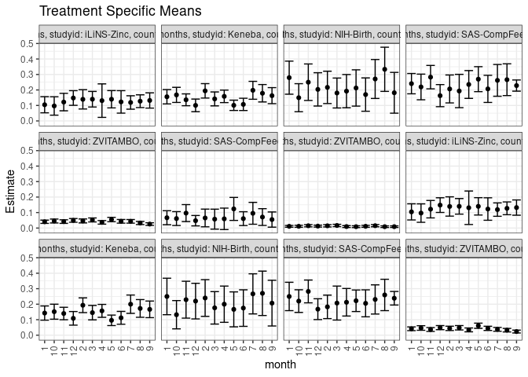

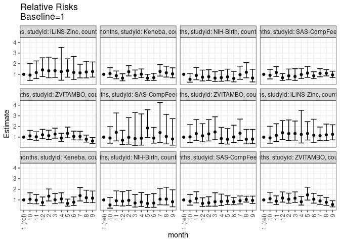

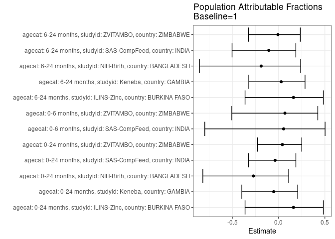

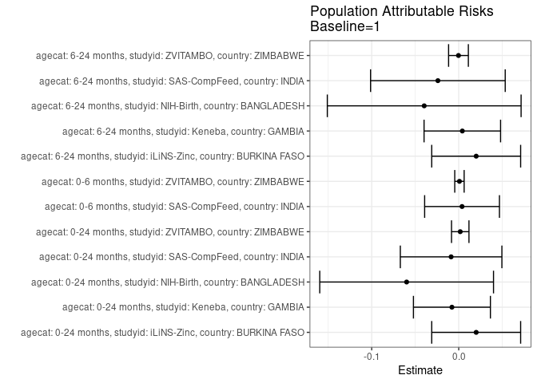

## Results Table

### Parameter: TSM

| agecat | studyid | country | intervention_level | baseline_level | estimate | ci_lower | ci_upper |
| --- | --- | --- | --- | --- | --- | --- | --- |
| 0-24 months | iLiNS-Zinc | BURKINA FASO | 1 | NA | 0.1046025 | 0.0524969 | 0.1567081 |
| 0-24 months | iLiNS-Zinc | BURKINA FASO | 2 | NA | 0.1394231 | 0.0771751 | 0.2016711 |
| 0-24 months | iLiNS-Zinc | BURKINA FASO | 3 | NA | 0.1401869 | 0.0898832 | 0.1904906 |
| 0-24 months | iLiNS-Zinc | BURKINA FASO | 4 | NA | 0.1311475 | 0.0231083 | 0.2391868 |
| 0-24 months | iLiNS-Zinc | BURKINA FASO | 5 | NA | 0.1400778 | 0.0842065 | 0.1959491 |
| 0-24 months | iLiNS-Zinc | BURKINA FASO | 6 | NA | 0.1229508 | 0.0504818 | 0.1954199 |
| 0-24 months | iLiNS-Zinc | BURKINA FASO | 7 | NA | 0.1192214 | 0.0759736 | 0.1624693 |
| 0-24 months | iLiNS-Zinc | BURKINA FASO | 8 | NA | 0.1274238 | 0.0862404 | 0.1686072 |
| 0-24 months | iLiNS-Zinc | BURKINA FASO | 9 | NA | 0.1322034 | 0.0829592 | 0.1814476 |
| 0-24 months | iLiNS-Zinc | BURKINA FASO | 10 | NA | 0.0967742 | 0.0372366 | 0.1563118 |
| 0-24 months | iLiNS-Zinc | BURKINA FASO | 11 | NA | 0.1218274 | 0.0655337 | 0.1781211 |
| 0-24 months | iLiNS-Zinc | BURKINA FASO | 12 | NA | 0.1481481 | 0.1007601 | 0.1955362 |
| 0-24 months | Keneba | GAMBIA | 1 | NA | 0.1561181 | 0.1098996 | 0.2023367 |
| 0-24 months | Keneba | GAMBIA | 2 | NA | 0.1942446 | 0.1477314 | 0.2407578 |
| 0-24 months | Keneba | GAMBIA | 3 | NA | 0.1422414 | 0.0972868 | 0.1871960 |
| 0-24 months | Keneba | GAMBIA | 4 | NA | 0.1587302 | 0.1183689 | 0.1990914 |
| 0-24 months | Keneba | GAMBIA | 5 | NA | 0.1009464 | 0.0677775 | 0.1341153 |
| 0-24 months | Keneba | GAMBIA | 6 | NA | 0.1068376 | 0.0672516 | 0.1464236 |
| 0-24 months | Keneba | GAMBIA | 7 | NA | 0.1978022 | 0.1399202 | 0.2556842 |
| 0-24 months | Keneba | GAMBIA | 8 | NA | 0.1787709 | 0.1226304 | 0.2349115 |
| 0-24 months | Keneba | GAMBIA | 9 | NA | 0.1632653 | 0.1115123 | 0.2150183 |
| 0-24 months | Keneba | GAMBIA | 10 | NA | 0.1681416 | 0.1193741 | 0.2169091 |
| 0-24 months | Keneba | GAMBIA | 11 | NA | 0.1363636 | 0.0980316 | 0.1746957 |
| 0-24 months | Keneba | GAMBIA | 12 | NA | 0.1004785 | 0.0597131 | 0.1412439 |
| 0-24 months | NIH-Birth | BANGLADESH | 1 | NA | 0.2794118 | 0.1726765 | 0.3861470 |
| 0-24 months | NIH-Birth | BANGLADESH | 2 | NA | 0.2166667 | 0.1123413 | 0.3209921 |
| 0-24 months | NIH-Birth | BANGLADESH | 3 | NA | 0.1803279 | 0.0837710 | 0.2768847 |
| 0-24 months | NIH-Birth | BANGLADESH | 4 | NA | 0.1923077 | 0.0851025 | 0.2995129 |
| 0-24 months | NIH-Birth | BANGLADESH | 5 | NA | 0.2127660 | 0.0956677 | 0.3298642 |
| 0-24 months | NIH-Birth | BANGLADESH | 6 | NA | 0.1702128 | 0.0626835 | 0.2777421 |

[output cut: 114 more lines]

### Parameter: E(Y)

| agecat | studyid | country | intervention_level | baseline_level | estimate | ci_lower | ci_upper |
| --- | --- | --- | --- | --- | --- | --- | --- |
| 0-24 months | iLiNS-Zinc | BURKINA FASO | NA | NA | 0.1246554 | 0.1041227 | 0.1451882 |
| 0-24 months | Keneba | GAMBIA | NA | NA | 0.1483007 | 0.1353925 | 0.1612090 |
| 0-24 months | NIH-Birth | BANGLADESH | NA | NA | 0.2195513 | 0.1870467 | 0.2520558 |
| 0-24 months | SAS-CompFeed | INDIA | NA | NA | 0.2319894 | 0.1917264 | 0.2722524 |
| 0-24 months | ZVITAMBO | ZIMBABWE | NA | NA | 0.0423899 | 0.0390454 | 0.0457344 |
| 0-6 months | SAS-CompFeed | INDIA | NA | NA | 0.0704787 | 0.0478990 | 0.0930584 |
| 0-6 months | ZVITAMBO | ZIMBABWE | NA | NA | 0.0120612 | 0.0102430 | 0.0138795 |
| 6-24 months | iLiNS-Zinc | BURKINA FASO | NA | NA | 0.1246554 | 0.1041227 | 0.1451882 |
| 6-24 months | Keneba | GAMBIA | NA | NA | 0.1469835 | 0.1337108 | 0.1602563 |
| 6-24 months | NIH-Birth | BANGLADESH | NA | NA | 0.2103321 | 0.1759902 | 0.2446740 |
| 6-24 months | SAS-CompFeed | INDIA | NA | NA | 0.2260619 | 0.1909133 | 0.2612105 |
| 6-24 months | ZVITAMBO | ZIMBABWE | NA | NA | 0.0410617 | 0.0373214 | 0.0448020 |

### Parameter: RR

| agecat | studyid | country | intervention_level | baseline_level | estimate | ci_lower | ci_upper |
| --- | --- | --- | --- | --- | --- | --- | --- |
| 0-24 months | iLiNS-Zinc | BURKINA FASO | 1 | 1 | 1.0000000 | 1.0000000 | 1.0000000 |
| 0-24 months | iLiNS-Zinc | BURKINA FASO | 2 | 1 | 1.3328846 | 0.6796226 | 2.6140705 |
| 0-24 months | iLiNS-Zinc | BURKINA FASO | 3 | 1 | 1.3401869 | 0.7155801 | 2.5099930 |
| 0-24 months | iLiNS-Zinc | BURKINA FASO | 4 | 1 | 1.2537705 | 0.4460802 | 3.5238967 |
| 0-24 months | iLiNS-Zinc | BURKINA FASO | 5 | 1 | 1.3391440 | 0.7309399 | 2.4534254 |
| 0-24 months | iLiNS-Zinc | BURKINA FASO | 6 | 1 | 1.1754098 | 0.5149448 | 2.6829833 |
| 0-24 months | iLiNS-Zinc | BURKINA FASO | 7 | 1 | 1.1397567 | 0.6673252 | 1.9466450 |
| 0-24 months | iLiNS-Zinc | BURKINA FASO | 8 | 1 | 1.2181717 | 0.6670519 | 2.2246281 |
| 0-24 months | iLiNS-Zinc | BURKINA FASO | 9 | 1 | 1.2638644 | 0.7392554 | 2.1607596 |
| 0-24 months | iLiNS-Zinc | BURKINA FASO | 10 | 1 | 0.9251613 | 0.4234959 | 2.0210901 |
| 0-24 months | iLiNS-Zinc | BURKINA FASO | 11 | 1 | 1.1646701 | 0.6010815 | 2.2566930 |
| 0-24 months | iLiNS-Zinc | BURKINA FASO | 12 | 1 | 1.4162963 | 0.7854964 | 2.5536657 |
| 0-24 months | Keneba | GAMBIA | 1 | 1 | 1.0000000 | 1.0000000 | 1.0000000 |
| 0-24 months | Keneba | GAMBIA | 2 | 1 | 1.2442154 | 0.8502178 | 1.8207948 |
| 0-24 months | Keneba | GAMBIA | 3 | 1 | 0.9111137 | 0.5908852 | 1.4048890 |
| 0-24 months | Keneba | GAMBIA | 4 | 1 | 1.0167310 | 0.6882075 | 1.5020788 |
| 0-24 months | Keneba | GAMBIA | 5 | 1 | 0.6466024 | 0.4154883 | 1.0062731 |
| 0-24 months | Keneba | GAMBIA | 6 | 1 | 0.6843382 | 0.4258898 | 1.0996243 |
| 0-24 months | Keneba | GAMBIA | 7 | 1 | 1.2670033 | 0.8355979 | 1.9211361 |
| 0-24 months | Keneba | GAMBIA | 8 | 1 | 1.1451004 | 0.7437204 | 1.7631020 |
| 0-24 months | Keneba | GAMBIA | 9 | 1 | 1.0457805 | 0.6777541 | 1.6136485 |
| 0-24 months | Keneba | GAMBIA | 10 | 1 | 1.0770151 | 0.7115893 | 1.6300996 |
| 0-24 months | Keneba | GAMBIA | 11 | 1 | 0.8734644 | 0.5806939 | 1.3138419 |
| 0-24 months | Keneba | GAMBIA | 12 | 1 | 0.6436053 | 0.3894919 | 1.0635081 |
| 0-24 months | NIH-Birth | BANGLADESH | 1 | 1 | 1.0000000 | 1.0000000 | 1.0000000 |
| 0-24 months | NIH-Birth | BANGLADESH | 2 | 1 | 0.7754386 | 0.4193897 | 1.4337621 |
| 0-24 months | NIH-Birth | BANGLADESH | 3 | 1 | 0.6453840 | 0.3343197 | 1.2458748 |
| 0-24 months | NIH-Birth | BANGLADESH | 4 | 1 | 0.6882591 | 0.3501544 | 1.3528333 |
| 0-24 months | NIH-Birth | BANGLADESH | 5 | 1 | 0.7614782 | 0.3896776 | 1.4880224 |
| 0-24 months | NIH-Birth | BANGLADESH | 6 | 1 | 0.6091825 | 0.2911586 | 1.2745744 |

[output cut: 114 more lines]

### Parameter: PAR

| agecat | studyid | country | intervention_level | baseline_level | estimate | ci_lower | ci_upper |
| --- | --- | --- | --- | --- | --- | --- | --- |
| 0-24 months | iLiNS-Zinc | BURKINA FASO | 1 | NA | 0.0200529 | -0.0310272 | 0.0711330 |
| 0-24 months | Keneba | GAMBIA | 1 | NA | -0.0078174 | -0.0520349 | 0.0364000 |
| 0-24 months | NIH-Birth | BANGLADESH | 1 | NA | -0.0598605 | -0.1596903 | 0.0399694 |
| 0-24 months | SAS-CompFeed | INDIA | 1 | NA | -0.0087513 | -0.0671061 | 0.0496035 |
| 0-24 months | ZVITAMBO | ZIMBABWE | 1 | NA | 0.0017395 | -0.0082817 | 0.0117607 |
| 0-6 months | SAS-CompFeed | INDIA | 1 | NA | 0.0038121 | -0.0391676 | 0.0467917 |
| 0-6 months | ZVITAMBO | ZIMBABWE | 1 | NA | 0.0008253 | -0.0045702 | 0.0062208 |
| 6-24 months | iLiNS-Zinc | BURKINA FASO | 1 | NA | 0.0200529 | -0.0310272 | 0.0711330 |
| 6-24 months | Keneba | GAMBIA | 1 | NA | 0.0041264 | -0.0398368 | 0.0480896 |
| 6-24 months | NIH-Birth | BANGLADESH | 1 | NA | -0.0396679 | -0.1509946 | 0.0716588 |
| 6-24 months | SAS-CompFeed | INDIA | 1 | NA | -0.0239381 | -0.1012991 | 0.0534229 |
| 6-24 months | ZVITAMBO | ZIMBABWE | 1 | NA | -0.0002917 | -0.0116478 | 0.0110644 |

### Parameter: PAF

| agecat | studyid | country | intervention_level | baseline_level | estimate | ci_lower | ci_upper |
| --- | --- | --- | --- | --- | --- | --- | --- |
| 0-24 months | iLiNS-Zinc | BURKINA FASO | 1 | NA | 0.1608668 | -0.3623252 | 0.4831304 |
| 0-24 months | Keneba | GAMBIA | 1 | NA | -0.0527133 | -0.3973538 | 0.2069258 |
| 0-24 months | NIH-Birth | BANGLADESH | 1 | NA | -0.2726492 | -0.8184535 | 0.1093333 |
| 0-24 months | SAS-CompFeed | INDIA | 1 | NA | -0.0377229 | -0.3237885 | 0.1865250 |
| 0-24 months | ZVITAMBO | ZIMBABWE | 1 | NA | 0.0410356 | -0.2270340 | 0.2505401 |
| 0-6 months | SAS-CompFeed | INDIA | 1 | NA | 0.0540881 | -0.7974566 | 0.5022136 |
| 0-6 months | ZVITAMBO | ZIMBABWE | 1 | NA | 0.0684249 | -0.5056093 | 0.4236007 |
| 6-24 months | iLiNS-Zinc | BURKINA FASO | 1 | NA | 0.1608668 | -0.3623252 | 0.4831304 |
| 6-24 months | Keneba | GAMBIA | 1 | NA | 0.0280739 | -0.3221500 | 0.2855271 |
| 6-24 months | NIH-Birth | BANGLADESH | 1 | NA | -0.1885965 | -0.8548494 | 0.2383416 |
| 6-24 months | SAS-CompFeed | INDIA | 1 | NA | -0.1058917 | -0.5027486 | 0.1861603 |
| 6-24 months | ZVITAMBO | ZIMBABWE | 1 | NA | -0.0071039 | -0.3253666 | 0.2347338 |